# STA141 Final Project

“Yinxuan Du (919787171)”

2024-03-17

## Abstract

This report analyzed the neuronal activity of mice using experimental data from Steinmetz et al. The main research question of this report is to build a predictive model to predict the outcome of each trial using the neural activity data. We evaluate the accuracy of our model through descriptive statistical analysis, data integration, model building, and result prediction.

## Introduction

Through literature review, we have learned that the feedback behavior of mice is closely related to neuronal activity. Different neurons are located in different brain regions, so there is a certain relationship between the peak values of neurons in different regions and the final feedback behavior of mice. We use this information to predict the feedback behavior of mice by summarizing the neuronal peaks in different brain regions for each experiment.

## Exploratory analysis

### Load the data

We read the data of 18 experiments in a loop manner.

```r
session=list()
for(i in 1:18){
  session[[i]]=readRDS(paste('./Data/session',i,'.rds',sep=''))
}
```

### Describe the data structures across sessions

Firstly, we describe the data structures in different sessions.

```r
# the number of neurons
sapply(session, function(x){length(x$brain_area)})
```

```
##  [1]  734 1070  619 1769 1077 1169  584 1157  788 1172  857  698  983  756  743
## [16]  474  565 1090
```

```r
# the number of trials
sapply(session, function(x){length(x$contrast_left)})
```

```
##  [1] 114 251 228 249 254 290 252 250 372 447 342 340 300 268 404 280 224 216
```

```r
#  stimuli conditions
sapply(session, function(x){sort(unique(c(x$contrast_left, x$contrast_right)))})
```

```
##      [,1] [,2] [,3] [,4] [,5] [,6] [,7] [,8] [,9] [,10] [,11] [,12] [,13] [,14]
## [1,] 0.00 0.00 0.00 0.00 0.00 0.00 0.00 0.00 0.00  0.00  0.00  0.00  0.00  0.00
## [2,] 0.25 0.25 0.25 0.25 0.25 0.25 0.25 0.25 0.25  0.25  0.25  0.25  0.25  0.25
## [3,] 0.50 0.50 0.50 0.50 0.50 0.50 0.50 0.50 0.50  0.50  0.50  0.50  0.50  0.50
## [4,] 1.00 1.00 1.00 1.00 1.00 1.00 1.00 1.00 1.00  1.00  1.00  1.00  1.00  1.00
##      [,15] [,16] [,17] [,18]
## [1,]  0.00  0.00  0.00  0.00
## [2,]  0.25  0.25  0.25  0.25
## [3,]  0.50  0.50  0.50  0.50
## [4,]  1.00  1.00  1.00  1.00
```

```r
# feedback types
sapply(session, function(x){sort(as.numeric(unique(x$feedback_type)))})
```

```
##      [,1] [,2] [,3] [,4] [,5] [,6] [,7] [,8] [,9] [,10] [,11] [,12] [,13] [,14]
## [1,]   -1   -1   -1   -1   -1   -1   -1   -1   -1    -1    -1    -1    -1    -1
## [2,]    1    1    1    1    1    1    1    1    1     1     1     1     1     1
##      [,15] [,16] [,17] [,18]
## [1,]    -1    -1    -1    -1
## [2,]     1     1     1     1
```

### Explore the neural activities during each trial

Taking the first experiment of the first session as an example, We demonstrated the peak number of neurons in different brain regions.

```r
rowSums(session[[1]]$spks[[1]])
```

[output not shown]

```r
aggregate(rowSums(session[[1]]$spks[[1]]), by = list(session[[1]]$brain_area), sum)
```

```
##   Group.1   x
## 1     ACA 138
## 2     CA3 104
## 3      DG  79
## 4      LS 269
## 5     MOs 106
## 6    root   9
## 7     SUB 156
## 8    VISp 300
```

### Explore the changes across trials

Taking the first session as an example, We visualized the peak number of neurons in different brain regions.

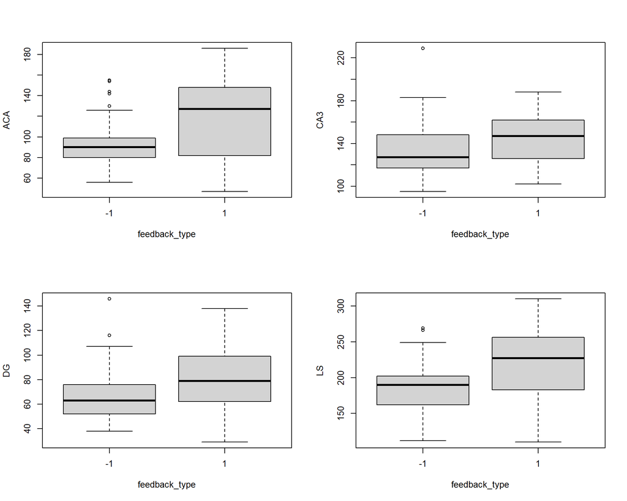

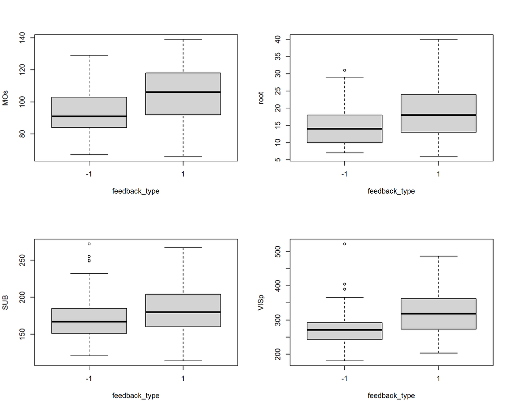

```r
peak_df <- matrix()
for(i in 1:length(session[[1]]$spks)){
  temp_df <- aggregate(rowSums(session[[1]]$spks[[i]]), by = list(session[[1]]$brain_area), sum)
  peak_df <- cbind(peak_df, temp_df)
}
peak_df <- peak_df[,-1]
rownames(peak_df) <- peak_df$Group.1
colnames(peak_df) <- NULL
peak_df <- peak_df[, -seq(1,ncol(peak_df),2)]
peak_df <- as.data.frame(t(peak_df))
peak_df$feedback_type <- as.factor(session[[1]]$feedback_type)

par(mfrow = c(2,2))
for(i in 1:8){
  boxplot(as.numeric(peak_df[,i])~peak_df$feedback_type,
          xlab = "feedback_type", ylab = names(peak_df)[i])
}
```

### Explore homogeneity and heterogeneity across sessions and mice

Finally, we summarized the types of brain regions in different sessions, and we can see that the types of brain regions in different experiments are different.

```r
for(i in 1:18){
  region <- unique(session[[i]]$brain_area)
  print(paste("The brain regions of session", i, "is :", paste(region, collapse = ",")))
}
```

```
## [1] "The brain regions of session 1 is : ACA,MOs,LS,root,VISp,CA3,SUB,DG"
## [1] "The brain regions of session 2 is : CA1,VISl,root,VISpm,POST"
## [1] "The brain regions of session 3 is : DG,VISam,MG,CA1,SPF,root,LP,MRN,POST,NB,VISp"
## [1] "The brain regions of session 4 is : LGd,DG,TH,SUB,VPL,VISp,CA1,VISa,LSr,ACA,MOs"
## [1] "The brain regions of session 5 is : VISa,root,CA1,SUB,DG,OLF,ORB,ACA,PL,MOs"
## [1] "The brain regions of session 6 is : AUD,root,SSp,CA1,TH"
## [1] "The brain regions of session 7 is : VPL,root,CA3,LD,CP,EPd,SSp,PIR"
## [1] "The brain regions of session 8 is : ILA,TT,MOs,PL,LSr,root,LD,PO,CA3,VISa,CA1,LP,DG,VISp,SUB"
## [1] "The brain regions of session 9 is : TT,ORBm,PL,LSr,root,CA3,VISl,CA1,TH,VISam,VPL,LD"
## [1] "The brain regions of session 10 is : MB,VISp,SCm,SCsg,POST,DG,MRN,CA1,VISl,POL,root,GPe,VISrl"
## [1] "The brain regions of session 11 is : MOp,LSc,root,PT,CP,LSr"
## [1] "The brain regions of session 12 is : VISp,DG,SUB,LGd,PL,root,MOs,ACA,CA1,VISam,MD,LH"
## [1] "The brain regions of session 13 is : VISam,ZI,DG,CA1,LGd,MB,SCs,RN,MRN,SCm,ACA,PL,MS,root,MOs"
## [1] "The brain regions of session 14 is : ORB,MOs,root,MRN,SCm,SCs,VISp,RSP,CA1,PAG"
## [1] "The brain regions of session 15 is : BLA,GPe,root,VPM,LGd,ZI,MB,CA3"
## [1] "The brain regions of session 16 is : SSs,SSp,MB,TH,LGd,CA3"
## [1] "The brain regions of session 17 is : root,VPL,VPM,RT,MEA,LD"
## [1] "The brain regions of session 18 is : CP,ACB,OT,SI,SNr,LGd,ZI,CA3,root,TH"
```

## Data integration

We first extract the peak number of different brain regions for each session, type of the feedback, contrast of the left stimulus, contrast of the right stimulus, the name of the mouse and the name of session. Then we will integrate data from different sessions to generate a new data frame, and then replace the missing values with 0.

```r
for(i in 1:length(session)) {
  peak_df <- matrix()
  for(j in 1:length(session[[i]]$spks)){
    temp_df <- aggregate(rowSums(session[[i]]$spks[[j]]),
                         by = list(session[[i]]$brain_area), sum)
    peak_df <- cbind(peak_df, temp_df)
  }
  peak_df <- peak_df[,-1]
  peak_df <- as.data.frame(peak_df)
  rownames(peak_df) <- peak_df$Group.1
  colnames(peak_df) <- NULL
  peak_df <- peak_df[, -seq(1,ncol(peak_df),2)]
  peak_df <- as.data.frame(t(peak_df))
  peak_df <- cbind(feedback_type = as.numeric(session[[i]]$feedback_type),
              contrast_left = as.numeric(session[[i]]$contrast_left),
              contrast_right = as.numeric(session[[i]]$contrast_right),
              mouse_name = session[[i]]$mouse_name,
              session_name = paste("session", i, sep = ""),
              peak_df)
  peak_df <- as.data.frame(t(peak_df))
  peak_df$names <- rownames(peak_df)
  if(i == 1) {
    dat <- peak_df
  }else{
    dat <- full_join(dat, peak_df, by = ("names" = "names"))
  }
}

dat <- as.data.frame(t(dat))
rownames(dat) <- NULL
names(dat) <- dat[115,]
dat <- dat[-115,]

for(i in 6:67){
  dat[,i] = as.numeric(dat[,i])
  dat[,i][is.na(dat[,i])] = 0
}

dat$feedback_type <- as.numeric(dat$feedback_type)
dat$contrast_left <- as.numeric(dat$contrast_left)
dat$contrast_right <- as.numeric(dat$contrast_right)
dat$feedback_type <- ifelse(dat$feedback_type == 1,1,0)
head(dat)
```

```
##   feedback_type contrast_left contrast_right mouse_name session_name ACA CA3
## 1             1           0.0            0.5       Cori     session1 138 104
## 2             1           0.0            0.0       Cori     session1  64 116
## 3             0           0.5            1.0       Cori     session1 130 135
## 4             0           0.0            0.0       Cori     session1  56 149
## 5             0           0.0            0.0       Cori     session1  84 123
## 6             1           0.0            0.0       Cori     session1  50 126
##    DG  LS MOs root SUB VISp CA1 POST VISl VISpm LP MG MRN NB SPF VISam LGd LSr
## 1  79 269 106    9 156  300   0    0    0     0  0  0   0  0   0     0   0   0
## 2  53 190  88   12 146  294   0    0    0     0  0  0   0  0   0     0   0   0
## 3 116 240 104   26 198  405   0    0    0     0  0  0   0  0   0     0   0   0
## 4  75 147  80   19 210  278   0    0    0     0  0  0   0  0   0     0   0   0
## 5  70 181  89   14 196  289   0    0    0     0  0  0   0  0   0     0   0   0
## 6  36 126  83   11 143  228   0    0    0     0  0  0   0  0   0     0   0   0
##   TH VISa VPL OLF ORB PL AUD SSp CP EPd LD PIR ILA PO TT ORBm GPe MB POL SCm
```

[output cut: 20 more lines]

## Predictive modeling

```r
set.seed(123)
ind <- createDataPartition(dat$feedback_type,  p = 0.7, list = FALSE)
train <- dat[ind, ]
test <- dat[-ind, ]
xgboost.mod <- xgboost(as.matrix(train[,-c(1,4,5)]), label = train$feedback_type,
                    nrounds = 10, objective = "binary:logistic")
xgboost.pred <- ifelse(predict(xgboost.mod, as.matrix(test[,-c(1,4,5)])) > 0.5, 1, 0)
mean(xgboost.pred == test$feedback_type)
```

```
## [1] 0.7171916
```

```r
final.mod <- xgboost(as.matrix(dat[,-c(1,4,5)]), label = dat$feedback_type,
                    nrounds = 10, objective = "binary:logistic")
```

## Prediction performance on the test sets

```r
test1 <- readRDS("test1.rds")
test2 <- readRDS("test1.rds")

session[[100]] <- test1
session[[101]] <- test2

for(i in 100:101) {
  peak_df <- matrix()
  for(j in 1:length(session[[i]]$spks)){
    temp_df <- aggregate(rowSums(session[[i]]$spks[[j]]),
                         by = list(session[[i]]$brain_area), sum)
    peak_df <- cbind(peak_df, temp_df)
  }
  peak_df <- peak_df[,-1]
  peak_df <- as.data.frame(peak_df)
  rownames(peak_df) <- peak_df$Group.1
  colnames(peak_df) <- NULL
  peak_df <- peak_df[, -seq(1,ncol(peak_df),2)]
  peak_df <- as.data.frame(t(peak_df))
  peak_df <- cbind(feedback_type = as.numeric(session[[i]]$feedback_type),
              contrast_left = as.numeric(session[[i]]$contrast_left),
              contrast_right = as.numeric(session[[i]]$contrast_right),
              mouse_name = session[[i]]$mouse_name,
              session_name = paste("session", i, sep = ""),
              peak_df)
  peak_df <- as.data.frame(t(peak_df))
  peak_df$names <- rownames(peak_df)
  if(i == 100) {
    dat1 <- peak_df
  }else{
    dat1 <- full_join(dat1, peak_df, by = ("names" = "names"))
  }
}

dat1<- full_join(dat1, data.frame(names = names(dat)), by = ("names" = "names"))
dat1 <- as.data.frame(t(dat1))
rownames(dat1) <- NULL
names(dat1) <- dat1[101,]
dat1 <- dat1[-101,]

for(i in 6:67){
  dat1[,i] = as.numeric(dat1[,i])
  dat1[,i][is.na(dat1[,i])] = 0
}

dat1$feedback_type <- as.numeric(dat1$feedback_type)
dat1$contrast_left <- as.numeric(dat1$contrast_left)
dat1$contrast_right <- as.numeric(dat1$contrast_right)
dat1$feedback_type <- ifelse(dat1$feedback_type == 1,1,0)

final.pred <- ifelse(predict(final.mod, as.matrix(dat1[,-c(1,4,5)])) > 0.5, 1, 0)
mean(final.pred == dat1$feedback_type)
```

```
## [1] 0.79
```

The accuray of test data set is 0.79.

## Discussion

This report models the data using XGBoost method and predicts the test dataset with an accuracy of 0.79. Next, we can adjust the parameters or use artificial intelligence methods to improve the performance of the model.